# 岡山大学 R講習 Rの基礎3

Ryota Chijimatsu

2022/5/18

# パッケージ

Rには元々備わっているbaseの機能以外に、用途に合わせた関数を多数含んだパッケージが配布されていて、パッケージを読み込むことで更なる機能が使えるようになります。  
配布元によってインストールコマンドが異なりますので、パッケージ名とインストール方法をググってパッケージに合わせたインストールを行ってください。

綺麗なグラフを作成できるパッケージのggplot2をインストールしてみます。

```r
install.packages("ggplot2")
```

パッケージはインストールするだけでは使えません。  
library機能でパッケージを読み込む必要があります。これはRを立ち上げる度に必要になります。

```r
# インストールされたパッケージは""で囲っても囲まなくても認識されます。
library(ggplot2)
```

# ggplot2でのグラフ作成

ggplot2でカッコいいグラフを描いてみます。Rに予め入っているデモデータのirisを使用します。

```r
# デモデータのirisを読み込み
data(iris)
# データの構造を確認
str(iris)
```

```
## 'data.frame':    150 obs. of  5 variables:
##  $ Sepal.Length: num  5.1 4.9 4.7 4.6 5 5.4 4.6 5 4.4 4.9 ...
##  $ Sepal.Width : num  3.5 3 3.2 3.1 3.6 3.9 3.4 3.4 2.9 3.1 ...
##  $ Petal.Length: num  1.4 1.4 1.3 1.5 1.4 1.7 1.4 1.5 1.4 1.5 ...
##  $ Petal.Width : num  0.2 0.2 0.2 0.2 0.2 0.4 0.3 0.2 0.2 0.1 ...
##  $ Species     : Factor w/ 3 levels "setosa","versicolor",..: 1 1 1 1 1 1 1 1 1 1 ...
```

```r
dim(iris)
```

```
## [1] 150   5
```

```r
head(iris)
```

|  | Sepal.Length | Sepal.Width | Petal.Length | Petal.Width | Species |
| --- | --- | --- | --- | --- | --- |
| 1 | 5.1 | 3.5 | 1.4 | 0.2 | setosa |
| 2 | 4.9 | 3.0 | 1.4 | 0.2 | setosa |
| 3 | 4.7 | 3.2 | 1.3 | 0.2 | setosa |
| 4 | 4.6 | 3.1 | 1.5 | 0.2 | setosa |
| 5 | 5.0 | 3.6 | 1.4 | 0.2 | setosa |
| 6 | 5.4 | 3.9 | 1.7 | 0.4 | setosa |

irisはアヤメという植物の花弁や萼を種別に調査したデータです。Species列が因子型 (Factor型)になっています。  
Speciesは3種類の品種から成っていますが、単純に文字列で表現せずに1, 2, 3のlevelが割り当てられています。  
同じ文字列を1つのカテゴリーにまとめた情報を持つデータ型がFactorです。  
因子の水準 (levels)には上下関係が無い質的要素です。

ggplotは豊富なデータ表現方法が用意されており、とても説明しきれません。日本語でも多数紹介されているので、自分が描きたいデータに合わせて調べてみてください。

# 基本的な書き方

- ggplot機能で大枠の情報を決める
  - data.frame型のdataを指定
  - aesに軸や色などに対応する変数 (data.frameの列名)を指定
- geom_シリーズでplotを追加していく

まず大枠の情報を作ります。引数は使うデータフレームと使う変数列の設定です。

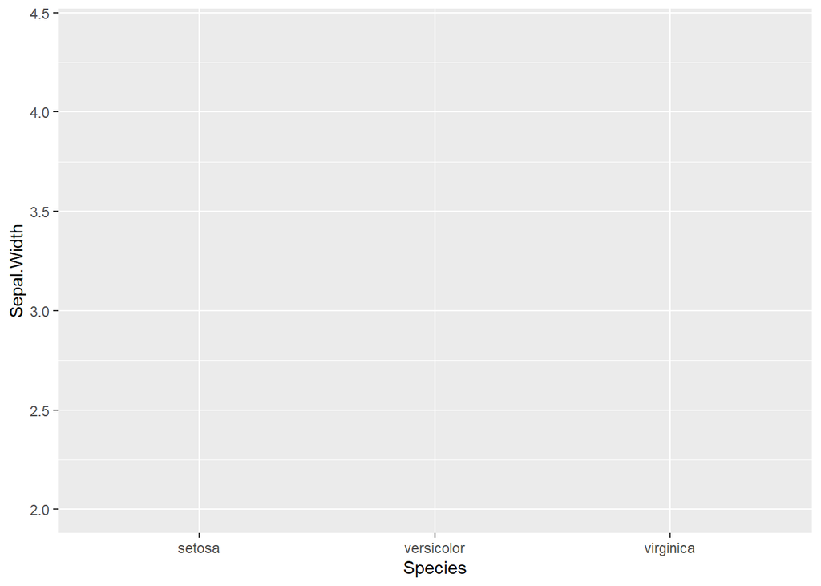

```r
ggplot(data = iris,  # <-- 使うデータフレーム
       # 使う変数列名の割り当て。列名を""無しで指定します。
       mapping = aes(x = Species, y = Sepal.Width)  # <-- ここではx軸にSpecies列、y軸にSepal.Widthが来るように指定しています。
       )
```

この大枠にgeom_シリーズのプロットコマンドを重ねていきます。

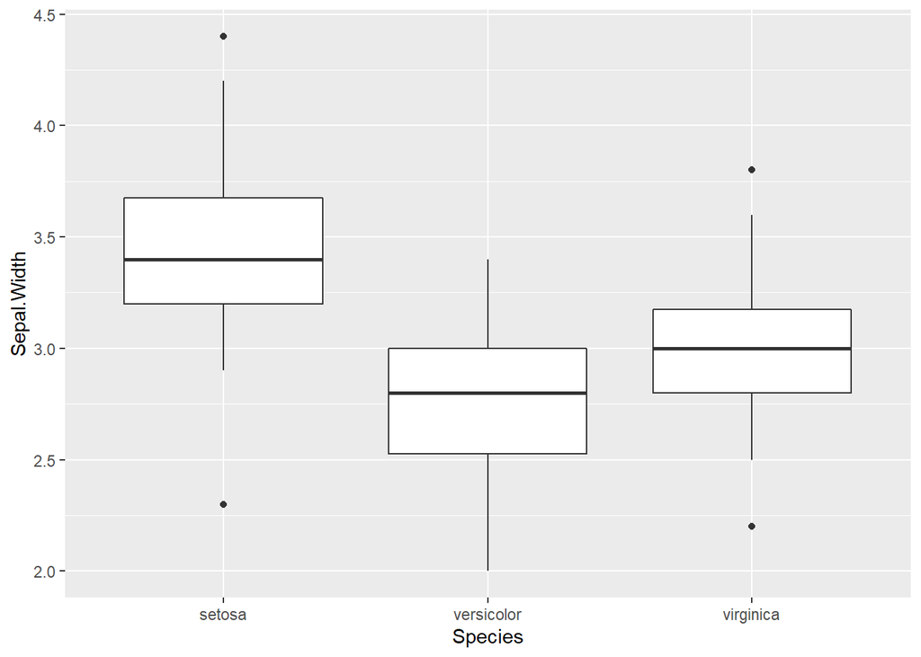

```r
ggplot(data = iris, aes(x = Species, y = Sepal.Width)) + geom_boxplot()
```

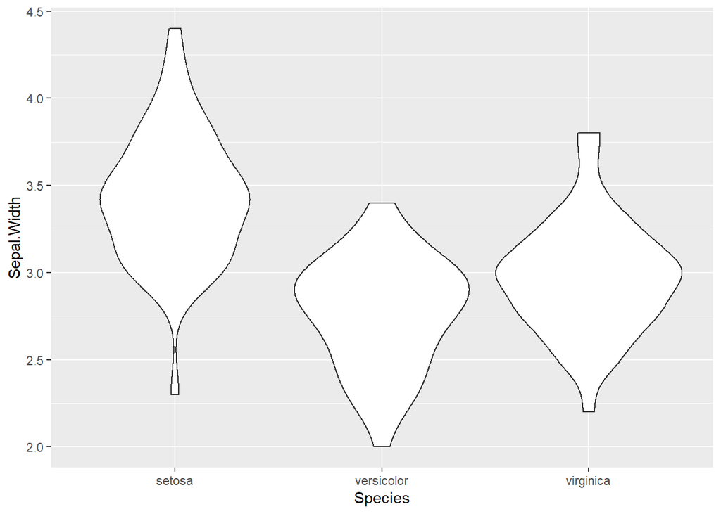

```r
ggplot(data = iris, aes(x = Species, y = Sepal.Width)) + geom_violin()
```

各データの分布を示す場合、geom_pointが使用できますが、データ量が多いと点が重なります。  
geom_jitterでは点をばらけさせて描画できます。

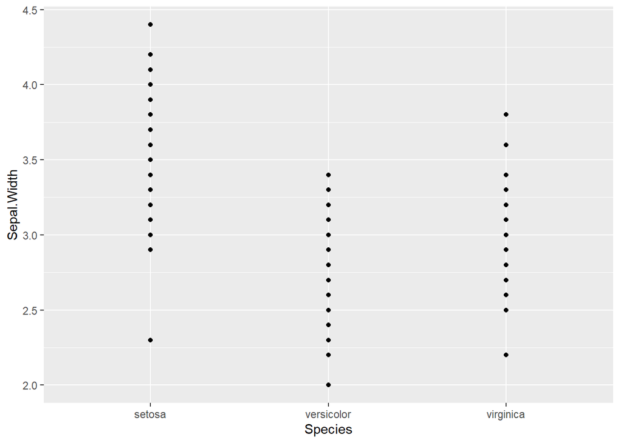

```r
ggplot(data = iris, aes(x = Species, y = Sepal.Width)) + geom_point()
```

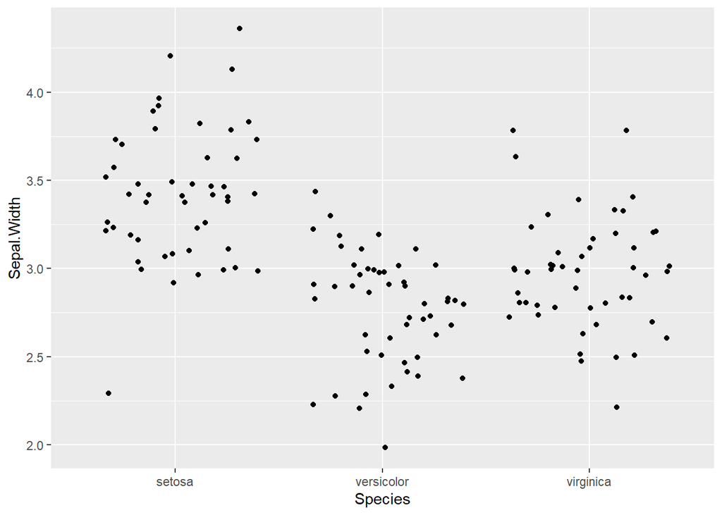

```r
ggplot(data = iris, aes(x = Species, y = Sepal.Width)) + geom_jitter()
```

## ggplot2でよく使用される図のプロットコマンド

| 表現内容 | コマンド | 注意するオプション |
| --- | --- | --- |
| 切片と傾きを指定した直線 | geom_abline() | intercept = 0, slope = 1 |
| 積み上げ折れ線グラフ | geom_area() |  |
| 棒グラフ | geom_bar() | stat = “bin or identity”, position = “stack or dodge” |
| タイル状に表現 | geom_bin2d() |  |
| 箱ヒゲ図 | geom_boxplot() | outlier.colour = “black”, outlier.shape = 16, outlier.size = 2, notch = FALSE, notchwidth = 0.5 *外れ値は箱の長さの1.5倍です。 |
| ドットプロット | geom_dotplot() | binaxis = “x”, method = “dotdensity”, binpositions = “bygroup”, stackdir = “up”, stackratio = 1, dotsize = 1, stackgroups = FALSE |
| エラーバー | geom_errorbar() | 水平方向のエラーバーにgeom_errorbarh()があります。 |
| 要素数を折れ線で表現 | geom_freqpoly() |  |
| ヒストグラム | geom_histogram() |  |
| 水平方向の線 | geom_hline() | 切片はyinterceptで指定します。垂直方向はgeom_vline()です。切片はxinterceptで指定します。 |
| ジッタープロット | geom_jitter(position = position_jitter()) | position_jitter()は横の振れ幅：width = 0.5と縦の振れ幅：height = 0.5があります。 |
| 折れ線グラフ | geom_line() | x軸は数字の小さい順からプロットされます。 |
| 要素の出現順に線で結ぶ | geom_path() |  |
| 散布図 | geom_point() |  |
| 指定した範囲を枠で囲む | geom_rect() |  |
| 指定した範囲の線分を描写 | geom_segment() |  |
| 文字列の描写 | geom_text() |  |
| バイオリンプロット | geom_violin() |  |